# program_assignment

Let’s follow the steps for **CROSS VALIDATION** outlined in slide 4 in the Cross Validation lecture for this course. For reference, the steps are listed as:

*Step 1: Use training set*

*Step 2: Split it into training/test sets*

*Step 3: Build a model on the training set*

*Step 4: Evaluate on the test set*

*Step 5: Repeat and average the errors*

Each section of this document represents one of these steps.

## Step 1: Use training set

So let’s load the full training set as “full_train”.

```r
full_train <- read.csv('https://d396qusza40orc.cloudfront.net/predmachlearn/pml-training.csv')
```

## Step 2: Split it into training/test sets

So before we even begin looking at the training data let’s break it up into subsets. This will allow us to perform **cross validation** on our model and estimate our out of sample error. We will be using the **Random subsampling** approach, so let’s split the “full_train” training set into two random subsamples, where the “training”" subset is 70% of the “full_train” set, and the “testing” subset is the remaining 30% of the “full_train” set.

```r
inTrain <- createDataPartition(y=full_train$classe, p=0.7, list=FALSE)
training <- full_train[inTrain,]
testing <- full_train[-inTrain,]
```

## Step 3: Build a model on the training set

Now let’s begin exploring the subset “training”. Remember, we want to build our model on our new “training” subset, and leave the “testing”" subset alone, so that we can perform **cross validation**. Since we are interested in predicting the “classe” feature, let’s plot it with respect to some other features.

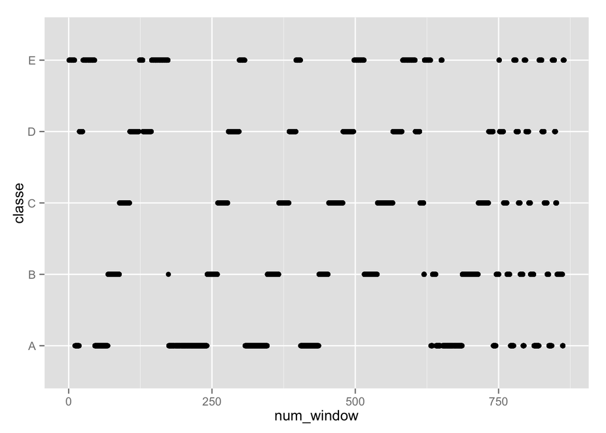

```r
qplot(num_window,classe,data=training)
```

Based on the figure above, it seems like the feature “num_window” will be useful in predicting “classe”. Notice how for many “num_window” values, there is only one “classe” value associated that given “num_window” value. In other words, if you know the value of “num_window”, you’d be able to predict the value of “classe”.

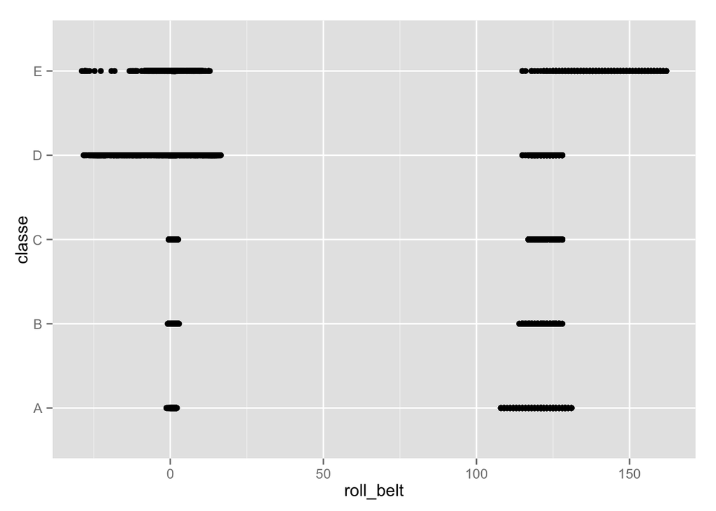

```r
qplot(roll_belt,classe,data=training)
```

The figure above shows there is also a relationship between the features “roll_belt” and “classe”. While not all values of “roll_belt” are associated with unique values of “classe”, it does appear that very high values of “roll_belt” are associated with with a “classe” value of E, and low values of “roll_belt” (except for those around 0) are associated with “classe” values of E or D. Therefore, the “roll_belt” feature may also be a useful feature in predicting “classe”.

Based on this analysis, let’s form a new data sets that takes only the “num_window” and “roll_belt” features. We will pull these features from our “training” subset.

```r
new_train <- training[,c("num_window", "roll_belt")]
```

Now we need to actually *build* a model. Since the “classe” feature is a classification (as opposed to a continuous numerical value), we probably want a classification model. Random forests are useful for building classification models, so let’s take that approach.

Here we build a random forest model called “newModel” with the “num_window” and “roll_belt” features of our “training” subset.

```r
newModel <- train(training$classe ~ ., method="rf", data=new_train)
```

Now we are ready to test this model on our “testing” subset.

## Step 4: Evaluate on the test set

First we will need to apply the same proccesing we applied to the “training” subset (i.e., extract onlt the “num_window” and “roll_belt” features) to our “testing” subset.

```r
new_test <- testing[,c("num_window", "roll_belt")]
```

Since the “classe” feature is a classification value (rather than a continuout numerical value) we’ll use a confusion matrix to obtain the error of this model on our testing subset.

```r
evalModel <- confusionMatrix(testing$classe,predict(newModel,new_test))
```

Let’s take a look at the accuracy from the output of our confusion matrix.

```r
evalModel$overall['Accuracy']
```

```
## Accuracy
##        1
```

We see from the above output that the accuracy of our model is 1. The error of this model can be calculated a 1 - Accuracy, and is found to be 0. Let’s save this value for reference.

```r
model1_err <- 1-evalModel$overall[['Accuracy']]
```

## Step 5: Repeat and average the errors

In order to perform **cross validation** and **estimate our out of sample error** , we need to repeat the above 4 steps on different random subsamples of our “full_train” training set.

First let’s remove previous results, so that we are sure our new results are based on the new subsamples.

```r
rm(inTrain)
rm(training)
rm(testing)
rm(new_train)
rm(new_test)
rm(newModel)
rm(evalModel)
```

I’ll just show the steps here without description, because we are simply repeating the exact same steps as described above, after creating new subsamples.

```r
inTrain <- createDataPartition(y=full_train$classe, p=0.7, list=FALSE)
training <- full_train[inTrain,]
testing <- full_train[-inTrain,]
new_train <- training[,c("num_window", "roll_belt")]
newModel <- train(training$classe ~ ., method="rf", data=new_train)
new_test <- testing[,c("num_window", "roll_belt")]
evalModel <- confusionMatrix(testing$classe,predict(newModel,new_test))
model2_err <- 1 - evalModel$overall[['Accuracy']]
model2_err
```

```
## [1] 0
```

We find the error of this model applied to the new “testing”" subsample is 0.

Let’s remove these results:

```r
rm(inTrain)
rm(training)
rm(testing)
rm(new_train)
rm(new_test)
rm(newModel)
rm(evalModel)
```

And try one more time:

```r
inTrain <- createDataPartition(y=full_train$classe, p=0.7, list=FALSE)
training <- full_train[inTrain,]
testing <- full_train[-inTrain,]
new_train <- training[,c("num_window", "roll_belt")]
newModel <- train(training$classe ~ ., method="rf", data=new_train)
new_test <- testing[,c("num_window", "roll_belt")]
evalModel <- confusionMatrix(testing$classe,predict(newModel,new_test))
model3_err <- 1 - evalModel$overall[['Accuracy']]
model3_err
```

```
## [1] 0.0001699235
```

```r
out_of_sample_error <- mean(model1_err, model2_err, model3_err)
out_of_sample_error
```

```
## [1] 0
```